# Cifar10_Image_Classification

```python
import os
os.environ['TF_CPP_MIN_LOG_LEVEL'] = '2'

#import important libraries
import numpy as np
import pandas as pd
import random
from keras.datasets import cifar10

# import libraries for EDA and preprocessing
import matplotlib.pyplot as plt
import seaborn as sns
from keras.preprocessing.image import ImageDataGenerator
from keras.utils import np_utils

# Modeling
from keras.models import *
from keras.layers import *
from keras.optimizers import Adam
from keras.callbacks import EarlyStopping, ModelCheckpoint, ReduceLROnPlateau
from tensorflow.keras.utils import plot_model

# Evaluating
from sklearn.metrics import roc_curve, auc, roc_auc_score
from sklearn.metrics import classification_report,confusion_matrix
```

## Part 1: Brief description of the problem and data

### 1.1 Problem

Deep learning is a type of machine learning based on artificial neural networks that teaches computers to do what comes naturally to humans: learn by example. In deep learning, a computer model learns to perform classification tasks directly from images, text, or sound. Image classification is one of the most important applications of deep learning, refers to assigning labels to images based on certain characteristics or features present in them. The algorithm identifies these features and uses them to differentiate different images and assign labels to them. In this project, my goal is to classify images from CIFAR-10 dataset by training Convolutional Neural Networks (CNNs). To achieve this goal, I will:

- Load in the data.
- EDA - Inspect, Visualize, and Clean the data.
- Building and training models:
  - Model 1: CNN with two layers
  - Model 2: CNN with two layers adding dropout
  - Model 3: CNN with three layers adding dropout
  - Model 4: CNN with three layers adding Earlystopping and ReduceLROnPlateau
  - Model 5: Resnet50 Model with "Imagenet" pretrained weights
  - Model 6: Resnet101 Model with "Imagenet" pretrained weights
- Results and Analysis, compare 6 models.
- Build the best model with tuning hyperparameters.
- Conclusion.

Here, I will compare these six deep learning models by roc_auc_score because it is generally seen as a more important measure of how good an algorithm is. This metric considers the trade-offs between precision and recall, while Accuracy only looks at how many predictions are correct. It tells us what is the probability that a randomly chosen positive instance is ranked higher than a randomly chosen negative instance. Since we care about true negatives as much as we care about true positives then it totally makes sense to use roc_auc_score.

Reference Sources:  
(1) https://www.tensorflow.org/api_docs/python/tf/keras/datasets/cifar10/load_data  
(2) https://neptune.ai/blog/f1-score-accuracy-roc-auc-pr-auc

### 1.2 Data

In this project, I use CIFAR-10 dataset from keras datasets module.

CIFAR-10 is a collection of images used to train Machine Learning and Computer Vision algorithms, used for object recognition. It is a subset of the 80 million tiny images dataset and consists of 60,000 32x32 color images containing one of 10 object classes, with 6000 images per class. It was collected by Alex Krizhevsky, Vinod Nair, and Geoffrey Hinton.

There are 50,000 training images and 10,000 test images, labeled over 10 categories in the official data.

The label classes in the dataset are:

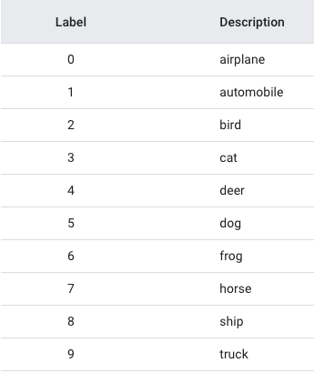

#### Loading the data

```python
(x_train, y_train), (x_test, y_test) = cifar10.load_data()
```

## Part 2: Exploratory Data Analysis (EDA)

### 2.1 Inspect the data

```python
# get the shape of the dataset
print("The shape of x_train: ", x_train.shape)
print("The shape of x_test: ", x_test.shape)
print("The shape of y_train: ", y_train.shape)
print("The shape of y_test: ", y_test.shape)
```

```
The shape of x_train:  (50000, 32, 32, 3)
The shape of x_test:  (10000, 32, 32, 3)
The shape of y_train:  (50000, 1)
The shape of y_test:  (10000, 1)
```

```python
# view some first rows of y_train
train_df = pd.DataFrame(y_train, columns=["label"])
train_df.head()
```

|  | label |
| --- | --- |
| 0 | 6 |
| 1 | 9 |
| 2 | 9 |
| 3 | 4 |
| 4 | 1 |

```python
# the structure of data also tells us the number of rows, columns and type of data
train_df.info()
```

```
<class 'pandas.core.frame.DataFrame'>
RangeIndex: 50000 entries, 0 to 49999
Data columns (total 1 columns):
 #   Column  Non-Null Count  Dtype
---  ------  --------------  -----
 0   label   50000 non-null  uint8
dtypes: uint8(1)
memory usage: 49.0 KB
```

```python
# get the unique labels in training data
train_df["label"].unique()
```

```
array([6, 9, 4, 1, 2, 7, 8, 3, 5, 0], dtype=uint8)
```

```python
# view some first rows of y_test
test_df = pd.DataFrame(y_test, columns=["label"])
test_df.head()
```

|  | label |
| --- | --- |
| 0 | 3 |
| 1 | 8 |
| 2 | 8 |
| 3 | 0 |
| 4 | 6 |

```python
# the structure of data also tells us the number of rows, columns and type of data
test_df.info()
```

```
<class 'pandas.core.frame.DataFrame'>
RangeIndex: 10000 entries, 0 to 9999
Data columns (total 1 columns):
 #   Column  Non-Null Count  Dtype
---  ------  --------------  -----
 0   label   10000 non-null  uint8
dtypes: uint8(1)
memory usage: 9.9 KB
```

```python
# get the unique labels in test data
test_df["label"].unique()
```

```
array([3, 8, 0, 6, 1, 9, 5, 7, 4, 2], dtype=uint8)
```

### 2.2 Visualize the data

#### Training data

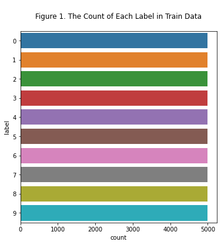

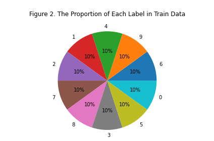

```python
# plot the count of each label
fig, ax = plt.subplots(figsize=(6,6))
sns.countplot(data=train_df, y='label', ax=ax).set(title='\nFigure 1. The Count of Each Label in Train Data\n')

# plot the proportion of each label
labels = train_df['label'].unique().tolist()
counts = train_df['label'].value_counts()
sizes = [counts[v] for v in labels]
fig1, ax1 = plt.subplots()
ax1.pie(sizes, labels=labels, autopct='%0.0f%%')
ax1.axis('equal')
plt.title("\nFigure 2. The Proportion of Each Label in Train Data\n")
plt.tight_layout()
plt.show()
```

From Figure 1 and 2, we can see that there are 5000 images per class and the proportion of each class is 10% in the training data.

#### Test data

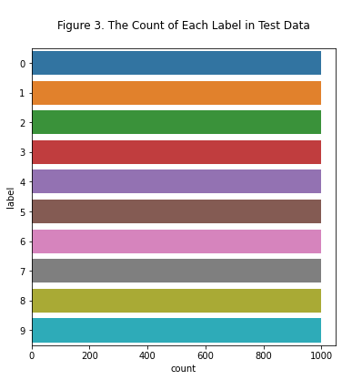

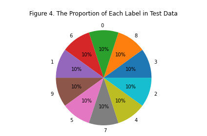

```python
# plot the count of each label
fig, ax = plt.subplots(figsize=(6,6))
sns.countplot(data=test_df, y='label', ax=ax).set(title='\nFigure 3. The Count of Each Label in Test Data\n')

# plot the proportion of each label
labels = test_df['label'].unique().tolist()
counts = test_df['label'].value_counts()
sizes = [counts[v] for v in labels]
fig1, ax1 = plt.subplots()
ax1.pie(sizes, labels=labels, autopct='%0.0f%%')
ax1.axis('equal')
plt.title("\nFigure 4. The Proportion of Each Label in Test Data\n")
plt.tight_layout()
plt.show()
```

From Figure 3 and 4, we can see that there are 1000 images per class and the proportion of each class is 10% in the test data.

```python
# create a list of class
classes = ['Airplane','Automobile','Bird','Cat','Deer','Dog','Frog','Horse','Ship','Truck']
```

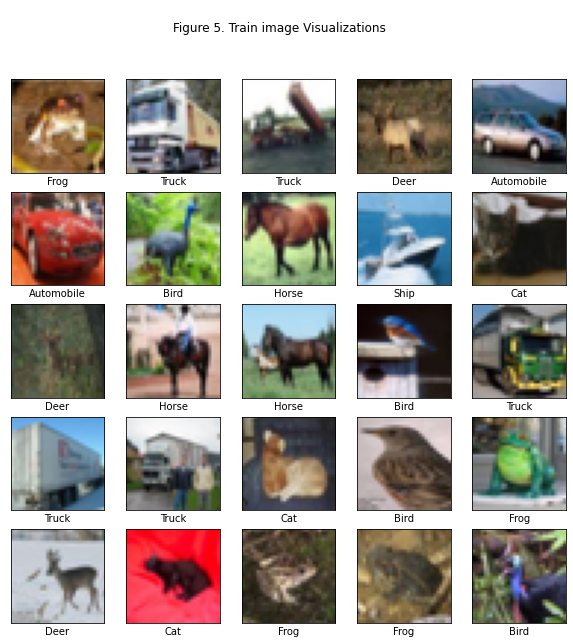

```python
# visualize some images in train data
fig, axes = plt.subplots(5, 5, figsize=(10, 10))
for i, ax in enumerate(axes.flat):
    ax.imshow(x_train[i])
    ax.set(xticks=[], yticks=[], xlabel = classes[y_train[i][0]])
fig.suptitle('\nFigure 5. Train image Visualizations')
plt.show()
```

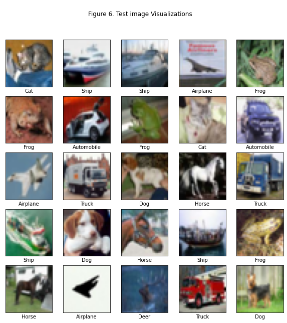

```python
# visualize some images in test data
fig, axes = plt.subplots(5, 5, figsize=(10, 10))
for i, ax in enumerate(axes.flat):
    ax.imshow(x_test[i])
    ax.set(xticks=[], yticks=[], xlabel = classes[y_test[i][0]])
fig.suptitle('\nFigure 6. Test image Visualizations')
plt.show()
```

From the output above, we can summarize that:

- There are 50,000 images labeled over 10 categories in training data.
- There are 10,000 images labeled over 10 categories in test data.
- There is no missing values.
- The shape of each image is (32,32,3).
- All categories are in balance, with each category distribution at 10%.

### 2.3 Data Preprocessing

Before we can proceed with building the model, I will:

(1) perform the one-hot encoding for labels  
(2) set random_state, batch_size, number of categories, input_shape, epochs, step_size_train, step_size_test  
(3) To work with neural networks, we need to normalize the dataset, otherwise, it could take a lot longer for the network to converge on a solution. As we are working with 32 x 32 NumPy arrays representing each image and each pixel in the array has an intensity somewhere between 1 — 255, a simpler way of getting all of these images on a scale between 0–1 is to divide each array by 255. To make our model much more accurate we can add data augmentation on our data.

```python
# perform the one-hot encoding for labels
y_train = np_utils.to_categorical(y_train)
y_test = np_utils.to_categorical(y_test)
print("There are {} training images, labeled over {} categories.".format(y_train.shape[0], y_train.shape[1]))
print("There are {} test images, labeled over {} categories.".format(y_test.shape[0], y_test.shape[1]))
```

```
There are 50000 training images, labeled over 10 categories.
There are 10000 test images, labeled over 10 categories.
```

```python
# view some first rows of y_train after encoding
y_train[:5]
```

```
array([[0., 0., 0., 0., 0., 0., 1., 0., 0., 0.],
       [0., 0., 0., 0., 0., 0., 0., 0., 0., 1.],
       [0., 0., 0., 0., 0., 0., 0., 0., 0., 1.],
       [0., 0., 0., 0., 1., 0., 0., 0., 0., 0.],
       [0., 1., 0., 0., 0., 0., 0., 0., 0., 0.]], dtype=float32)
```

```python
# set random state
RANDOM_STATE = 42

# set batch size
BATCH_SIZE = 64

# set input shape
INPUT_SHAPE = x_train.shape[1:]

# set the number of categories
NUM_LABELS = y_train.shape[1]

# set the number of epochs
EPOCHS = 20

# set step_size_train and step_size_test
STEP_SIZE_TRAIN = x_train.shape[0]//BATCH_SIZE
STEP_SIZE_TEST = x_test.shape[0]//BATCH_SIZE
```

```python
# train data augmentation
train_datagen = ImageDataGenerator(featurewise_center=False,  # set input mean to 0 over the dataset
                              featurewise_std_normalization=False,# divide inputs by std of the dataset
                              zoom_range = 0.2, # Randomly zoom image
                              rotation_range = 20,  # randomly rotate images in the range (degrees, 0 to 180)
                              width_shift_range=3/32,  # randomly shift images horizontally (fraction of total width)
                              height_shift_range=3/32,  # randomly shift images vertically (fraction of total height)
                              horizontal_flip = True,  # randomly flip image
                              rescale = 1./255)    # multiply the data by the value provided
train_generator = train_datagen.flow(x_train, y_train, batch_size=BATCH_SIZE)

# test data augmentation
test_datagen = ImageDataGenerator(rescale = 1./255)
test_generator = test_datagen.flow(x_test, y_test, batch_size=BATCH_SIZE)
```

## Part 3: Building and Training models

Convolutional Neural Networks are used for classifying and recognizing images because of its high accuracy and its built-in convolutional layer reduces the high dimensionality of images without losing its information. A CNN follows a hierarchical model which works on building a network, like a funnel, and finally gives out a fully connected layer where all the neurons are connected to each other and the output is processed. That is why CNNs are especially suited for image classification.

In this project, I will build and train 4 different CNNs and 2 different ResNets model:

### Model 1: Convolutional Neural Network (CNN)

Model 1 is comprised of:

A simple CNN model with 2 Convolutional layers followed by max-pooling layers. BatchNormalization normalize the activation of the previous layer at each batch. Softmax is used as the activation function for the final layer of the category classifier. Use categorical_crossentropy loss function for our category-class classification problem because we have more than two labels. For simplicity, use accuracy as our evaluation metrics to evaluate the model during training and testing.

Architecture:

- two convolutional layers
- hidden layer activations: relu
- BatchNormalization
- pool_size: (2,2)
- final layer activation: softmax

```python
# build CNN model
model1 = Sequential()
# first convolutional layer
model1.add(Conv2D(64, (3, 3), input_shape=INPUT_SHAPE))
model1.add(BatchNormalization())
model1.add(Activation('relu'))
model1.add(MaxPooling2D(pool_size=(2, 2)))

# second convolutional layer
model1.add(Conv2D(128, (3, 3)))
model1.add(BatchNormalization())
model1.add(Activation('relu'))
model1.add(MaxPooling2D(pool_size=(2, 2)))

model1.add(Flatten())
model1.add(Dense(256))
model1.add(BatchNormalization())
model1.add(Activation('relu'))

# Out layer
model1.add(Dense(NUM_LABELS))
model1.add(Activation('softmax'))

# summary model 1
model1.summary()
```

```
Model: "sequential"
_________________________________________________________________
 Layer (type)                Output Shape              Param #
=================================================================
 conv2d (Conv2D)             (None, 30, 30, 64)        1792

 batch_normalization (BatchN  (None, 30, 30, 64)       256
 ormalization)

 activation (Activation)     (None, 30, 30, 64)        0

 max_pooling2d (MaxPooling2D  (None, 15, 15, 64)       0
 )

 conv2d_1 (Conv2D)           (None, 13, 13, 128)       73856

 batch_normalization_1 (Batc  (None, 13, 13, 128)      512
 hNormalization)

 activation_1 (Activation)   (None, 13, 13, 128)       0

 max_pooling2d_1 (MaxPooling  (None, 6, 6, 128)        0
 2D)

 flatten (Flatten)           (None, 4608)              0

 dense (Dense)               (None, 256)               1179904

 batch_normalization_2 (Batc  (None, 256)              1024
 hNormalization)

 activation_2 (Activation)   (None, 256)               0

 dense_1 (Dense)             (None, 10)                2570

 activation_3 (Activation)   (None, 10)                0

=================================================================
Total params: 1,259,914
Trainable params: 1,259,018
Non-trainable params: 896
_________________________________________________________________
```

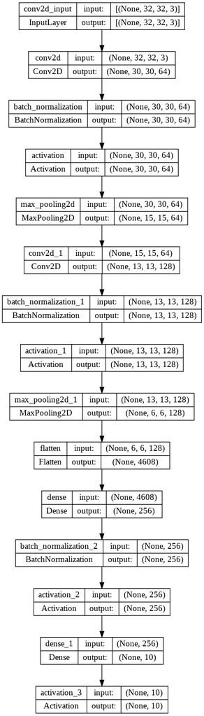

```python
# plot model 1
plot_model(model1, show_shapes=True, show_layer_names=True)
```

Let's compile the model now using:

```python
# compile the model
model1.compile(loss='categorical_crossentropy',
              optimizer='adam',
              metrics=['accuracy'])
```

```python
# let’s train our model for 20 epochs
res1 = model1.fit(train_generator,
                epochs = EPOCHS,
                verbose = 1,
                steps_per_epoch=STEP_SIZE_TRAIN,
                validation_steps=STEP_SIZE_TEST,
                validation_data = test_generator)
```

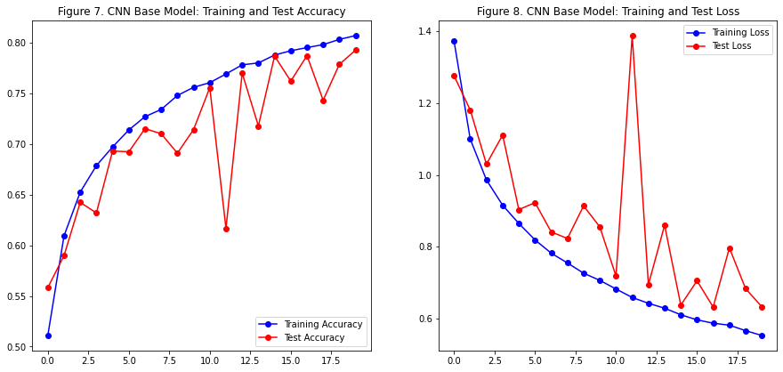

```python
# plot the graph of accuracy
epochs_range = range(EPOCHS)

acc1 = res1.history['accuracy']
test_acc1 = res1.history['val_accuracy']
plt.figure(figsize=(15, 15))
plt.subplot(2, 2, 1)
plt.plot(epochs_range, acc1, label='Training Accuracy', color = "blue", marker = "o")
plt.plot(epochs_range, test_acc1, label='Test Accuracy', color = "red", marker = "o")
plt.legend(loc='lower right')
plt.title('Figure 7. CNN Base Model: Training and Test Accuracy')

# plot the graph of loss
loss1 = res1.history['loss']
test_loss1 = res1.history['val_loss']
plt.subplot(2, 2, 2)
plt.plot(epochs_range, loss1, label='Training Loss', color = "blue", marker = "o")
plt.plot(epochs_range, test_loss1, label='Test Loss', color = "red", marker = "o")
plt.legend(loc='upper right')
plt.title('Figure 8. CNN Base Model: Training and Test Loss')
plt.show()
```

### Model 2: CNN with two layers and adding dropout

Model 2 is comprised of:

A CNN with two layers adding dropout at each convolutional layer to avoid overfitting. Dropout is a technique where randomly selected neurons are ignored during training. This means that their contribution to the activation of downstream neurons is temporally removed on the forward pass, and any weight updates are not applied to the neuron on the backward pass. When we have training data, if we try to train our model too much, it might overfit, and dropout regularization is one technique used to tackle overfitting problems in deep learning.

Architecture:

- two convolutional layers
- hidden layer activations: relu
- BatchNormalization
- pool_size: (2,2)
- dropout: 0.2
- final layer activation: softmax

```python
# build CNN model adding dropout

model2 = Sequential()
# first convolutional layer
model2.add(Conv2D(64, (3, 3), input_shape=INPUT_SHAPE))
model2.add(BatchNormalization())
model2.add(Activation('relu'))
model2.add(MaxPooling2D(pool_size=(2, 2)))
model2.add(Dropout(0.2))

# second convolutional layer
model2.add(Conv2D(128, (3, 3)))
model2.add(BatchNormalization())
model2.add(Activation('relu'))
model2.add(MaxPooling2D(pool_size=(2, 2)))
model2.add(Dropout(0.2))

model2.add(Flatten())
model2.add(Dense(256))
model2.add(BatchNormalization())
model2.add(Activation('relu'))
model2.add(Dropout(0.2))

# Out layer
model2.add(Dense(NUM_LABELS))
model2.add(Activation('softmax'))

# summary model 2
model2.summary()
```

```
Model: "sequential_1"
_________________________________________________________________
 Layer (type)                Output Shape              Param #
=================================================================
 conv2d_2 (Conv2D)           (None, 30, 30, 64)        1792

 batch_normalization_3 (Batc  (None, 30, 30, 64)       256
 hNormalization)

 activation_4 (Activation)   (None, 30, 30, 64)        0

 max_pooling2d_2 (MaxPooling  (None, 15, 15, 64)       0
 2D)

 dropout (Dropout)           (None, 15, 15, 64)        0

 conv2d_3 (Conv2D)           (None, 13, 13, 128)       73856

 batch_normalization_4 (Batc  (None, 13, 13, 128)      512
 hNormalization)

 activation_5 (Activation)   (None, 13, 13, 128)       0

 max_pooling2d_3 (MaxPooling  (None, 6, 6, 128)        0
 2D)

 dropout_1 (Dropout)         (None, 6, 6, 128)         0

 flatten_1 (Flatten)         (None, 4608)              0

 dense_2 (Dense)             (None, 256)               1179904

 batch_normalization_5 (Batc  (None, 256)              1024
 hNormalization)

 activation_6 (Activation)   (None, 256)               0

 dropout_2 (Dropout)         (None, 256)               0

 dense_3 (Dense)             (None, 10)                2570

 activation_7 (Activation)   (None, 10)                0

=================================================================
Total params: 1,259,914
Trainable params: 1,259,018
Non-trainable params: 896
_________________________________________________________________
```

```python
# compile the model 2
model2.compile(loss='categorical_crossentropy',
              optimizer='adam',
              metrics=['accuracy'])
```

```python
# let’s train our model for 20 epochs
res2 = model2.fit(train_generator,
                epochs = EPOCHS,
                steps_per_epoch=STEP_SIZE_TRAIN,
                validation_steps=STEP_SIZE_TEST,
                verbose = 1,
                validation_data = test_generator)
```

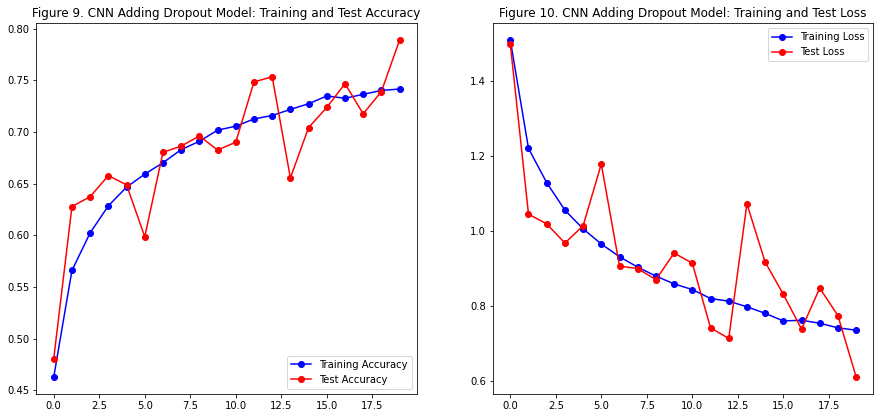

```python
# plot the graph of accuracy
epochs_range = range(EPOCHS)

acc2 = res2.history['accuracy']
test_acc2 = res2.history['val_accuracy']
plt.figure(figsize=(15, 15))
plt.subplot(2, 2, 1)
plt.plot(epochs_range, acc2, label='Training Accuracy', color = "blue", marker = "o")
plt.plot(epochs_range, test_acc2, label='Test Accuracy', color = "red", marker = "o")
plt.legend(loc='lower right')
plt.title('Figure 9. CNN Adding Dropout Model: Training and Test Accuracy')

# plot the graph of loss
loss2 = res2.history['loss']
test_loss2 = res2.history['val_loss']
plt.subplot(2, 2, 2)
plt.plot(epochs_range, loss2, label='Training Loss', color = "blue", marker = "o")
plt.plot(epochs_range, test_loss2, label='Test Loss', color = "red", marker = "o")
plt.legend(loc='upper right')
plt.title('Figure 10. CNN Adding Dropout Model: Training and Test Loss')
plt.show()
```

### Model 3: CNN with three layers and adding dropout

Model 3 is comprised of:

A CNN from model 2 but adding one more convolutional layer to see which result will we get.

Architecture:

- three convolutional layers
- hidden layer activations: relu
- BatchNormalization
- pool_size: (2,2)
- dropout: 0.2
- final layer activation: softmax

```python
# build CNN model adding more layers with more filters
model3 = Sequential()
# first convolutional layer
model3.add(Conv2D(64, (3, 3), input_shape=INPUT_SHAPE))
model3.add(BatchNormalization())
model3.add(Activation('relu'))
model3.add(MaxPooling2D(pool_size=(2, 2)))
model3.add(Dropout(0.2))

# second convolutional layer
model3.add(Conv2D(128, (3, 3)))
model3.add(BatchNormalization())
model3.add(Activation('relu'))
model3.add(MaxPooling2D(pool_size=(2, 2)))
model3.add(Dropout(0.2))

# third convolutional layer
model3.add(Conv2D(64, (3, 3)))
model3.add(BatchNormalization())
model3.add(Activation('relu'))
model3.add(MaxPooling2D(pool_size=(2, 2)))
model3.add(Dropout(0.2))

model3.add(Flatten())
model3.add(Dense(256))
model3.add(BatchNormalization())
model3.add(Activation('relu'))
model3.add(Dropout(0.2))

# Out layer
model3.add(Dense(NUM_LABELS))
model3.add(Activation('softmax'))

# summary model 3
model3.summary()
```

```
Model: "sequential_2"
_________________________________________________________________
 Layer (type)                Output Shape              Param #
=================================================================
 conv2d_4 (Conv2D)           (None, 30, 30, 64)        1792

 batch_normalization_6 (Batc  (None, 30, 30, 64)       256
 hNormalization)

 activation_8 (Activation)   (None, 30, 30, 64)        0

 max_pooling2d_4 (MaxPooling  (None, 15, 15, 64)       0
 2D)

 dropout_3 (Dropout)         (None, 15, 15, 64)        0

 conv2d_5 (Conv2D)           (None, 13, 13, 128)       73856

 batch_normalization_7 (Batc  (None, 13, 13, 128)      512
 hNormalization)

 activation_9 (Activation)   (None, 13, 13, 128)       0

 max_pooling2d_5 (MaxPooling  (None, 6, 6, 128)        0
 2D)

 dropout_4 (Dropout)         (None, 6, 6, 128)         0

 conv2d_6 (Conv2D)           (None, 4, 4, 64)          73792

 batch_normalization_8 (Batc  (None, 4, 4, 64)         256
 hNormalization)

 activation_10 (Activation)  (None, 4, 4, 64)          0

 max_pooling2d_6 (MaxPooling  (None, 2, 2, 64)         0
 2D)

 dropout_5 (Dropout)         (None, 2, 2, 64)          0

 flatten_2 (Flatten)         (None, 256)               0

 dense_4 (Dense)             (None, 256)               65792

 batch_normalization_9 (Batc  (None, 256)              1024
 hNormalization)

 activation_11 (Activation)  (None, 256)               0

 dropout_6 (Dropout)         (None, 256)               0

 dense_5 (Dense)             (None, 10)                2570

 activation_12 (Activation)  (None, 10)                0

=================================================================
Total params: 219,850
Trainable params: 218,826
Non-trainable params: 1,024
_________________________________________________________________
```

```python
# compile the model 3
model3.compile(loss='categorical_crossentropy',
              optimizer='adam',
              metrics=['accuracy'])
```

```python
# let’s train our model for 20 epochs
res3 = model3.fit(train_generator,
                epochs = EPOCHS,
                steps_per_epoch=STEP_SIZE_TRAIN,
                validation_steps=STEP_SIZE_TEST,
                verbose = 1,
                validation_data = test_generator)
```

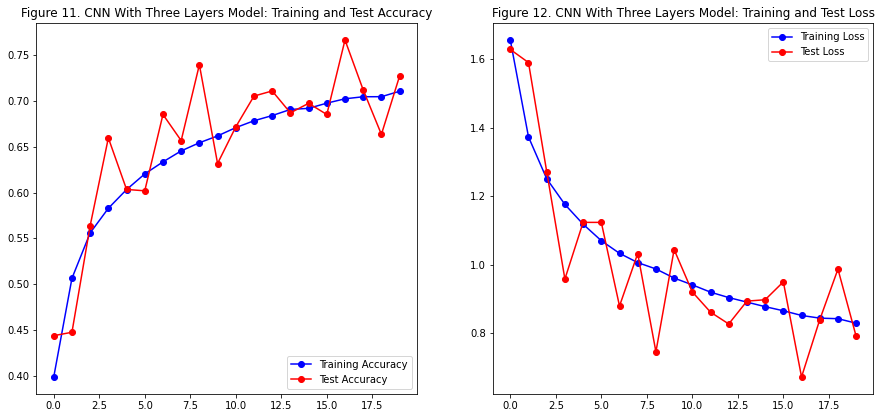

```python
# plot the graph of accuracy
epochs_range = range(EPOCHS)

acc3 = res3.history['accuracy']
test_acc3 = res3.history['val_accuracy']
plt.figure(figsize=(15, 15))
plt.subplot(2, 2, 1)
plt.plot(epochs_range, acc3, label='Training Accuracy', color = "blue", marker = "o")
plt.plot(epochs_range, test_acc3, label='Test Accuracy', color = "red", marker = "o")
plt.legend(loc='lower right')
plt.title('Figure 11. CNN With Three Layers Model: Training and Test Accuracy')

# plot the graph of loss
loss3 = res3.history['loss']
test_loss3 = res3.history['val_loss']
plt.subplot(2, 2, 2)
plt.plot(epochs_range, loss3, label='Training Loss', color = "blue", marker = "o")
plt.plot(epochs_range, test_loss3, label='Test Loss', color = "red", marker = "o")
plt.legend(loc='upper right')
plt.title('Figure 12. CNN With Three Layers Model: Training and Test Loss')
plt.show()
```

### Model 4: CNN with three layers using Earlystopping and ReduceLROnPlateau

Next, let's use Earlystopping to avoid overfitting by terminating the process early. Since the goal of a training is to maximize the validation accuracy, so we can set up the metrics as:

```
+ monitor = "val_acc": value being monitored.
+ mode = "max": training will stop when the quantity monitored has stopped inreasing.
+ patience = 5: number of epochs with no improvement after which training will be stopped.
```

Moreover, let's use Reduce learning rate when a metric has stopped improving. Models often benefit from reducing the learning rate by a factor of 2-10 once learning stagnates. This callback monitors a quantity and if no improvement is seen for a 'patience' number of epochs, the learning rate is reduced.

```
+ factor = 0.5: factor by which the learning rate will be reduced (new_learning_rate = learning_rate * factor).
+ min_lr = 0.00001: lower bound on the learning rate.
```

A model.fit() training loop will check at end of every epoch whether the accuracy is no longer increasing, considering the monitor and patience if applicable. Once it's found no longer increasing, model.stop_training is marked True and the training terminates.

```python
# set up callback
es= tf.keras.callbacks.EarlyStopping(monitor='val_accuracy', mode='max', patience=5, verbose=1)
reduce_lr = ReduceLROnPlateau(monitor='val_accuracy', factor=0.5, patience=5,
                                   verbose=1, mode='max', min_lr=0.00001)
callback=[es, reduce_lr]
```

```python
# build CNN model adding more layers with more filters
model4 = Sequential()
# first convolutional layer
model4.add(Conv2D(32, (3, 3), input_shape=INPUT_SHAPE))
model4.add(BatchNormalization())
model4.add(Activation('relu'))
model4.add(MaxPooling2D(pool_size=(2, 2)))
model4.add(Dropout(0.2))

# second convolutional layer
model4.add(Conv2D(64, (3, 3)))
model4.add(BatchNormalization())
model4.add(Activation('relu'))
model4.add(MaxPooling2D(pool_size=(2, 2)))
model4.add(Dropout(0.2))

# third convolutional layer
model4.add(Conv2D(128, (3, 3)))
model4.add(BatchNormalization())
model4.add(Activation('relu'))
model4.add(MaxPooling2D(pool_size=(2, 2)))
model4.add(Dropout(0.2))

model4.add(Flatten())
model4.add(Dense(256))
model4.add(BatchNormalization())
model4.add(Activation('relu'))
model4.add(Dropout(0.2))

# Out layer
model4.add(Dense(NUM_LABELS))
model4.add(Activation('softmax'))

# summary model 4
model4.summary()
```

```
Model: "sequential_3"
_________________________________________________________________
 Layer (type)                Output Shape              Param #
=================================================================
 conv2d_7 (Conv2D)           (None, 30, 30, 32)        896

 batch_normalization_10 (Bat  (None, 30, 30, 32)       128
 chNormalization)

 activation_13 (Activation)  (None, 30, 30, 32)        0

 max_pooling2d_7 (MaxPooling  (None, 15, 15, 32)       0
 2D)

 dropout_7 (Dropout)         (None, 15, 15, 32)        0

 conv2d_8 (Conv2D)           (None, 13, 13, 64)        18496

 batch_normalization_11 (Bat  (None, 13, 13, 64)       256
 chNormalization)

 activation_14 (Activation)  (None, 13, 13, 64)        0

 max_pooling2d_8 (MaxPooling  (None, 6, 6, 64)         0
 2D)

 dropout_8 (Dropout)         (None, 6, 6, 64)          0

 conv2d_9 (Conv2D)           (None, 4, 4, 128)         73856

 batch_normalization_12 (Bat  (None, 4, 4, 128)        512
 chNormalization)

 activation_15 (Activation)  (None, 4, 4, 128)         0

 max_pooling2d_9 (MaxPooling  (None, 2, 2, 128)        0
 2D)

 dropout_9 (Dropout)         (None, 2, 2, 128)         0

 flatten_3 (Flatten)         (None, 512)               0

 dense_6 (Dense)             (None, 256)               131328

 batch_normalization_13 (Bat  (None, 256)              1024
 chNormalization)

 activation_16 (Activation)  (None, 256)               0

 dropout_10 (Dropout)        (None, 256)               0

 dense_7 (Dense)             (None, 10)                2570

 activation_17 (Activation)  (None, 10)                0

=================================================================
Total params: 229,066
Trainable params: 228,106
Non-trainable params: 960
_________________________________________________________________
```

```python
# compile the model 4
model4.compile(loss='categorical_crossentropy',
              optimizer='adam',
              metrics=['accuracy'])
```

```python
# let’s train our model for 20 epochs
res4 = model4.fit(train_generator,
                epochs = EPOCHS,
                steps_per_epoch=STEP_SIZE_TRAIN,
                validation_steps=STEP_SIZE_TEST,
                verbose = 1,
                validation_data = test_generator,
                callbacks=callback)
```

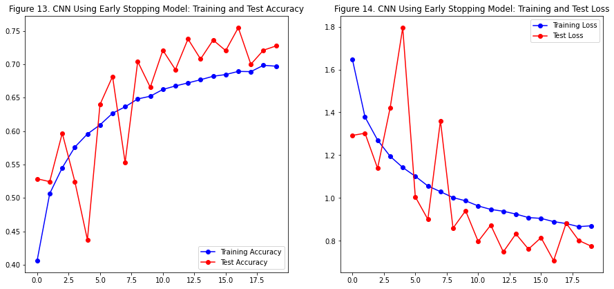

```python
# plot the graph of accuracy
epochs_range = range(20)

acc4 = res4.history['accuracy']
test_acc4 = res4.history['val_accuracy']
plt.figure(figsize=(15, 15))
plt.subplot(2, 2, 1)
plt.plot(epochs_range, acc4, label='Training Accuracy', color = "blue", marker = "o")
plt.plot(epochs_range, test_acc4, label='Test Accuracy', color = "red", marker = "o")
plt.legend(loc='lower right')
plt.title('Figure 13. CNN Using Early Stopping Model: Training and Test Accuracy')

# plot the graph of loss
loss4 = res4.history['loss']
test_loss4 = res4.history['val_loss']
plt.subplot(2, 2, 2)
plt.plot(epochs_range, loss4, label='Training Loss', color = "blue", marker = "o")
plt.plot(epochs_range, test_loss4, label='Test Loss', color = "red", marker = "o")
plt.legend(loc='upper right')
plt.title('Figure 14. CNN Using Early Stopping Model: Training and Test Loss')
plt.show()
```

### Model 5: ResNet50 Model with "Imagenet" pretrained weights

ResNet50 is a 50 layers convolutional neural network included 48 convolutional layers, one MaxPool layer, and one average pool layer. I choose to build a ResNet50 with "Imagenet" weights because the Imagenet database contains a pretrained version of the network that has been trained on more than a million photos of 1000 different item categories from the Imagenet dataset, including several animals, a keyboard, a mouse, and a pencil. Moreover, this model has over 23 million trainable parameters which indicates a deep architecture that makes it better for image classification.

So that's why here, we will train a ResNet50 model with taking the "Imagenet" pretrained weights file loaded and repurposing it for cifar10 image classification. It helps achieve higher performance even if the model is trained on a smaller datatset. Since the training time took so long, in this model we just trained with only 10 epochs.

```python
# build model 5
model5 = None
model5 = Sequential()
model5.add(UpSampling2D((2,2)))
model5.add(UpSampling2D((2,2)))
model5.add(UpSampling2D((2,2)))

resnet = tf.keras.applications.resnet50.ResNet50(include_top=False,
                                                 weights="imagenet",
                                                 pooling = "max",
                                                 classes=NUM_LABELS)
model5.add(resnet)
model5.add(Dropout(0.2))

# Out layer
model5.add(Dense(NUM_LABELS))
model5.add(Activation('softmax'))

model5.build(input_shape = (None, 32,32,3))

# summary model 5
model5.summary()
```

```
Model: "sequential_8"
_________________________________________________________________
 Layer (type)                Output Shape              Param #
=================================================================
 up_sampling2d_12 (UpSamplin  (None, 64, 64, 3)        0
 g2D)

 up_sampling2d_13 (UpSamplin  (None, 128, 128, 3)      0
 g2D)

 up_sampling2d_14 (UpSamplin  (None, 256, 256, 3)      0
 g2D)

 resnet50 (Functional)       (None, 2048)              23587712

 dropout_15 (Dropout)        (None, 2048)              0

 dense_16 (Dense)            (None, 10)                20490

 activation_26 (Activation)  (None, 10)                0

=================================================================
Total params: 23,608,202
Trainable params: 23,555,082
Non-trainable params: 53,120
_________________________________________________________________
```

```python
# compile the model 5
model5.compile(loss='categorical_crossentropy',
              optimizer='adam',
              metrics=['accuracy'])
```

```python
# let’s train our model for 10 epochs
res5 = model5.fit(train_generator,
                steps_per_epoch=STEP_SIZE_TRAIN,
                validation_steps=STEP_SIZE_TEST,
                epochs = 10,
                verbose = 1,
                validation_data = test_generator)
```

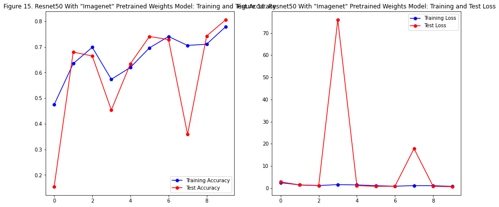

```python
# plot the graph of accuracy
epochs_range = range(10)

acc5 = res5.history['accuracy']
test_acc5 = res5.history['val_accuracy']
plt.figure(figsize=(15, 15))
plt.subplot(2, 2, 1)
plt.plot(epochs_range, acc5, label='Training Accuracy', color = "blue", marker = "o")
plt.plot(epochs_range, test_acc5, label='Test Accuracy', color = "red", marker = "o")
plt.legend(loc='lower right')
plt.title('Figure 15. Resnet50 With "Imagenet" Pretrained Weights Model: Training and Test Accuracy')

# plot the graph of loss
loss5 = res5.history['loss']
test_loss5 = res5.history['val_loss']
plt.subplot(2, 2, 2)
plt.plot(epochs_range, loss5, label='Training Loss', color = "blue", marker = "o")
plt.plot(epochs_range, test_loss5, label='Test Loss', color = "red", marker = "o")
plt.legend(loc='upper right')
plt.title('Figure 16. Resnet50 With "Imagenet" Pretrained Weights Model: Training and Test Loss')
plt.show()
```

### Model 6: ResNet101 With "Imagenet" pretrained weights

ResNet101 is a 101 layers convolutional neural network and here our model will also be trained with "Imagenet" pretrained weights file loaded.

```python
# build model 6
model6 = None
model6 = Sequential()
model6.add(UpSampling2D((2,2)))
model6.add(UpSampling2D((2,2)))
model6.add(UpSampling2D((2,2)))

resnet101 = tf.keras.applications.resnet.ResNet101(include_top=False,
                                                   weights="imagenet",
                                                   pooling = "max",
                                                   classes=NUM_LABELS)
model6.add(resnet101)
model6.add(Dropout(0.2))

# Out layer
model6.add(Dense(NUM_LABELS))
model6.add(Activation('softmax'))

model6.build(input_shape = (None, 32, 32, 3))

# summary model 6
model6.summary()
```

```
Model: "sequential_9"
_________________________________________________________________
 Layer (type)                Output Shape              Param #
=================================================================
 up_sampling2d_15 (UpSamplin  (None, 64, 64, 3)        0
 g2D)

 up_sampling2d_16 (UpSamplin  (None, 128, 128, 3)      0
 g2D)

 up_sampling2d_17 (UpSamplin  (None, 256, 256, 3)      0
 g2D)

 resnet101 (Functional)      (None, 2048)              42658176

 dropout_16 (Dropout)        (None, 2048)              0

 dense_17 (Dense)            (None, 10)                20490

 activation_27 (Activation)  (None, 10)                0

=================================================================
Total params: 42,678,666
Trainable params: 42,573,322
Non-trainable params: 105,344
_________________________________________________________________
```

```python
# compile the model 6
model6.compile(loss='categorical_crossentropy',
              optimizer='adam',
              metrics=['accuracy'])
```

```python
# let’s train our model for 10 epochs
res6 = model6.fit(train_generator,
                steps_per_epoch=STEP_SIZE_TRAIN,
                validation_steps=STEP_SIZE_TEST,
                epochs = 10,
                verbose = 1,
                validation_data = test_generator)
```

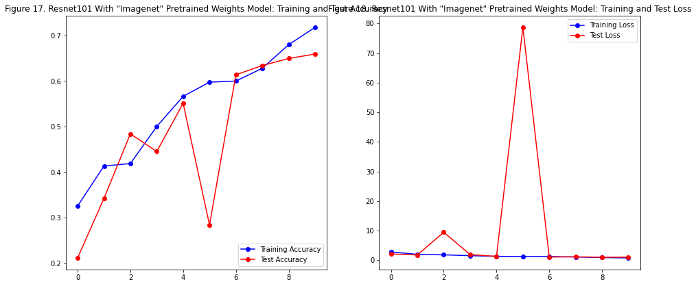

```python
# plot the graph of accuracy
epochs_range = range(10)

acc6 = res6.history['accuracy']
test_acc6 = res6.history['val_accuracy']
plt.figure(figsize=(15, 15))
plt.subplot(2, 2, 1)
plt.plot(epochs_range, acc6, label='Training Accuracy', color = "blue", marker = "o")
plt.plot(epochs_range, test_acc6, label='Test Accuracy', color = "red", marker = "o")
plt.legend(loc='lower right')
plt.title('Figure 17. Resnet101 With "Imagenet" Pretrained Weights Model: Training and Test Accuracy')

# plot the graph of loss
loss6 = res6.history['loss']
test_loss6 = res6.history['val_loss']
plt.subplot(2, 2, 2)
plt.plot(epochs_range, loss6, label='Training Loss', color = "blue", marker = "o")
plt.plot(epochs_range, test_loss6, label='Test Loss', color = "red", marker = "o")
plt.legend(loc='upper right')
plt.title('Figure 18. Resnet101 With "Imagenet" Pretrained Weights Model: Training and Test Loss')
plt.show()
```

## Part 4: Results and Analysis

```python
# Get the true labels
y_true = np.argmax(y_test, axis = 1)
```

```python
# x_test augmentation
x_test_datagen = test_datagen.flow(x_test, y=None, batch_size=BATCH_SIZE, shuffle=False)
```

### Model 1

```python
# get loss and accuracy score
train_loss1, train_acc1 = model1.evaluate(train_generator, verbose=0)
test_loss1, test_acc1 = model1.evaluate(test_generator, verbose=0)
print('train_loss_model1:', train_loss1)
print('train_acc_model1:', train_acc1)
print('test_loss_model1:', test_loss1)
print('test_acc_model1:', test_acc1)
```

```
train_loss_model1: 0.6362866163253784
train_acc_model1: 0.776639997959137
test_loss_model1: 0.6335040330886841
test_acc_model1: 0.7925000190734863
```

```python
# make predictions on the test dataset
y_predict1 = model1.predict(x_test_datagen)
```

```python
# calculate roc_auc_score
auc_score1 = roc_auc_score(y_test, y_predict1)
print('Model 1 roc_auc_score:', auc_score1)
```

```
Model 1 roc_auc_score: 0.9789955444444445
```

```python
# print out classification report
y_pred1 = np.argmax(y_predict1, axis=1)
print(classification_report(y_true, y_pred1))
```

```
              precision    recall  f1-score   support

           0       0.82      0.84      0.83      1000
           1       0.78      0.96      0.86      1000
           2       0.69      0.77      0.73      1000
           3       0.80      0.47      0.59      1000
           4       0.81      0.75      0.78      1000
           5       0.82      0.62      0.71      1000
           6       0.80      0.88      0.84      1000
           7       0.70      0.92      0.79      1000
           8       0.87      0.88      0.88      1000
           9       0.89      0.82      0.85      1000

    accuracy                           0.79     10000
   macro avg       0.80      0.79      0.79     10000
weighted avg       0.80      0.79      0.79     10000
```

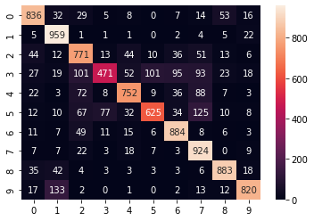

```python
# print out the confusion matrix
cm1 = confusion_matrix(y_true, y_pred1)
sns.heatmap(cm1, annot=True, fmt=".0f")
```

### Model 2

```python
# get loss and accuracy score
train_loss2, train_acc2 = model2.evaluate(train_generator, verbose=0)
test_loss2, test_acc2 = model2.evaluate(test_generator, verbose=0)
print('train_loss_model2:', train_loss2)
print('train_acc_model2:', train_acc2)
print('test_loss_model2:', test_loss2)
print('test_acc_model2:', test_acc2)
```

```
train_loss_model2: 0.6540790796279907
train_acc_model2: 0.7716400027275085
test_loss_model2: 0.6122938394546509
test_acc_model2: 0.7889999747276306
```

```python
# make predictions on the test dataset
y_predict2 = model2.predict(x_test_datagen)
```

```python
# calculate roc_auc_score
auc_score2 = roc_auc_score(y_test, y_predict2)
print('Model 2 roc_auc_score:', auc_score2)
```

```
Model 2 roc_auc_score: 0.9786542222222223
```

```python
# print out classification report
y_pred2 = np.argmax(y_predict2, axis= 1)
print(classification_report(y_true, y_pred2))
```

```
              precision    recall  f1-score   support

           0       0.84      0.78      0.81      1000
           1       0.87      0.90      0.89      1000
           2       0.89      0.56      0.69      1000
           3       0.69      0.58      0.63      1000
           4       0.81      0.74      0.77      1000
           5       0.70      0.74      0.72      1000
           6       0.81      0.89      0.85      1000
           7       0.74      0.91      0.81      1000
           8       0.86      0.87      0.87      1000
           9       0.73      0.92      0.81      1000

    accuracy                           0.79     10000
   macro avg       0.79      0.79      0.78     10000
weighted avg       0.79      0.79      0.78     10000
```

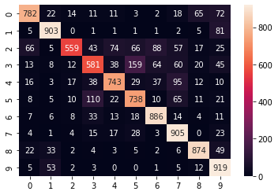

```python
# print out the confusion matrix
cm2 = confusion_matrix(y_true, y_pred2)
sns.heatmap(cm2, annot=True, fmt=".0f")
```

### Model 3

```python
# get loss and accuracy score
train_loss3, train_acc3 = model3.evaluate(train_generator, verbose=0)
test_loss3, test_acc3 = model3.evaluate(test_generator, verbose=0)
print('train_loss_model3:', train_loss3)
print('train_acc_model3:', train_acc3)
print('test_loss_model3:', test_loss3)
print('test_acc_model3:', test_acc3)
```

```
train_loss_model3: 0.8003495335578918
train_acc_model3: 0.7209399938583374
test_loss_model3: 0.7913793921470642
test_acc_model3: 0.7276999950408936
```

```python
# make predictions on the test dataset
y_predict3 = model3.predict(x_test_datagen)
```

```python
# calculate test roc_auc_score
auc_score3 = roc_auc_score(y_test, y_predict3)
print('Model 3 roc_auc_score:', auc_score3)
```

```
Model 3 roc_auc_score: 0.9695221444444444
```

```python
# print out classification report
y_pred3 = np.argmax(y_predict3, axis= 1)
print(classification_report(y_true, y_pred3))
```

```
              precision    recall  f1-score   support

           0       0.82      0.79      0.80      1000
           1       0.89      0.89      0.89      1000
           2       0.80      0.53      0.64      1000
           3       0.69      0.44      0.54      1000
           4       0.69      0.66      0.67      1000
           5       0.80      0.52      0.63      1000
           6       0.50      0.96      0.66      1000
           7       0.89      0.69      0.78      1000
           8       0.81      0.89      0.84      1000
           9       0.69      0.92      0.79      1000

    accuracy                           0.73     10000
   macro avg       0.76      0.73      0.72     10000
weighted avg       0.76      0.73      0.72     10000
```

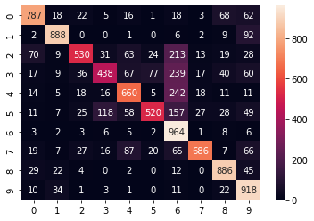

```python
# print out the confusion matrix
cm3 = confusion_matrix(y_true, y_pred3)
sns.heatmap(cm3, annot=True, fmt=".0f")
```

### Model 4

```python
# get loss and accuracy score
train_loss4, train_acc4 = model4.evaluate(train_generator, verbose=0)
test_loss4, test_acc4 = model4.evaluate(test_generator, verbose=0)
print('train_loss_model4:', train_loss4)
print('train_acc_model4:', train_acc4)
print('test_loss_model4:', test_loss4)
print('test_acc_model4:', test_acc4)
```

```
train_loss_model4: 0.9356865882873535
train_acc_model4: 0.6801599860191345
test_loss_model4: 0.7757894396781921
test_acc_model4: 0.7271999716758728
```

```python
# make predictions on the test dataset
y_predict4 = model4.predict(x_test_datagen)
```

```python
# calculate roc_auc_score
auc_score4 = roc_auc_score(y_test, y_predict4)
print('Model 4 roc_auc_score:', auc_score4)
```

```
Model 4 roc_auc_score: 0.9687030999999999
```

```python
# print out classification report
y_pred4 = np.argmax(y_predict4, axis= 1)
print(classification_report(y_true, y_pred4))
```

```
              precision    recall  f1-score   support

           0       0.90      0.60      0.72      1000
           1       0.91      0.86      0.88      1000
           2       0.81      0.42      0.55      1000
           3       0.55      0.61      0.58      1000
           4       0.70      0.66      0.67      1000
           5       0.62      0.73      0.67      1000
           6       0.57      0.93      0.71      1000
           7       0.81      0.78      0.80      1000
           8       0.83      0.84      0.83      1000
           9       0.80      0.87      0.83      1000

    accuracy                           0.73     10000
   macro avg       0.75      0.73      0.72     10000
weighted avg       0.75      0.73      0.72     10000
```

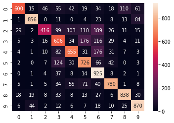

```python
# print out the confusion matrix
cm4 = confusion_matrix(y_true, y_pred4)
sns.heatmap(cm4, annot=True, fmt=".0f")
```

### Model 5

```python
# get loss and accuracy score
train_loss5, train_acc5 = model5.evaluate(train_generator, verbose=0)
test_loss5, test_acc5 = model5.evaluate(test_generator, verbose=0)
print('train_loss_model5:', train_loss5)
print('train_acc_model5:', train_acc5)
print('test_loss_model5:', test_loss5)
print('test_acc_model5:', test_acc5)
```

```
train_loss_model5: 0.5876865386962891
train_acc_model5: 0.8000199794769287
test_loss_model5: 0.5938641428947449
test_acc_model5: 0.8055999875068665
```

```python
# make predictions on the test dataset
y_predict5 = model5.predict(x_test_datagen)
```

```python
# calculate roc_auc_score
auc_score5 = roc_auc_score(y_test, y_predict5)
print('Model 5 roc_auc_score:', auc_score5)
```

```
Model 5 roc_auc_score: 0.9819706500000001
```

```python
# print out classification report
y_pred5 = np.argmax(y_predict5,  axis = 1)
print(classification_report(y_true, y_pred5))
```

```
              precision    recall  f1-score   support

           0       0.76      0.87      0.81      1000
           1       0.69      0.99      0.82      1000
           2       0.85      0.68      0.76      1000
           3       0.76      0.65      0.70      1000
           4       0.87      0.75      0.81      1000
           5       0.75      0.79      0.76      1000
           6       0.82      0.89      0.85      1000
           7       0.86      0.86      0.86      1000
           8       0.91      0.85      0.88      1000
           9       0.87      0.73      0.79      1000

    accuracy                           0.81     10000
   macro avg       0.81      0.81      0.80     10000
weighted avg       0.81      0.81      0.80     10000
```

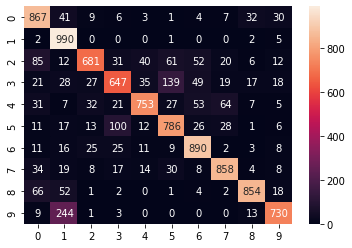

```python
# print out the confusion matrix
cm5 = confusion_matrix(y_true, y_pred5)
sns.heatmap(cm5, annot=True, fmt=".0f")
```

### Model 6

```python
# get loss and accuracy score
train_loss6, train_acc6 = model6.evaluate(train_generator, verbose=0)
test_loss6, test_acc6 = model6.evaluate(test_generator, verbose=0)
print('train_loss_model6:', train_loss6)
print('train_acc_model6:', train_acc6)
print('test_loss_model6:', test_loss6)
print('test_acc_model6:', test_acc6)
```

```
train_loss_model6: 1.0199801921844482
train_acc_model6: 0.6549999713897705
test_loss_model6: 1.0772815942764282
test_acc_model6: 0.659500002861023
```

```python
# make predictions on the test dataset
y_predict6 = model6.predict(x_test_datagen)
```

```python
# calculate roc_auc_score
auc_score6 = roc_auc_score(y_test, y_predict6)
print('Model 6 roc_auc_score:', auc_score6)
```

```
Model 6 roc_auc_score: 0.9561412333333333
```

```python
# print out classification report
y_pred6 = np.argmax(y_predict6, axis= 1)
print(classification_report(y_true, y_pred6))
```

```
              precision    recall  f1-score   support

           0       0.50      0.86      0.63      1000
           1       0.79      0.92      0.85      1000
           2       0.55      0.61      0.58      1000
           3       0.64      0.26      0.37      1000
           4       0.69      0.65      0.67      1000
           5       0.96      0.15      0.26      1000
           6       0.54      0.86      0.67      1000
           7       0.89      0.58      0.70      1000
           8       0.71      0.87      0.78      1000
           9       0.80      0.82      0.81      1000

    accuracy                           0.66     10000
   macro avg       0.71      0.66      0.63     10000
weighted avg       0.71      0.66      0.63     10000
```

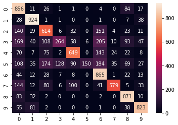

```python
# print out the confusion matrix
cm6 = confusion_matrix(y_true, y_pred6)
sns.heatmap(cm6, annot=True, fmt=".0f")
```

### Comparing 6 models

```python
# create compare dataframe to compare five models
models = {'Model': ["Model 1", "Model 2", "Model 3", "Model 4", "Model5", "Model6"],
        'Training Accuracy': [train_acc1, train_acc2, train_acc3, train_acc4, train_acc5, train_acc6],
        'Training Loss': [train_loss1, train_loss2, train_loss3, train_loss4, train_loss5, train_loss6],
        'Test Accuracy': [test_acc1, test_acc2, test_acc3, test_acc4, test_acc5, test_acc6],
        'Test Loss': [test_loss1, test_loss2, test_loss3, test_loss4, test_loss5, test_loss6],
        'roc_auc_score': [auc_score1, auc_score2, auc_score3, auc_score4, auc_score5, auc_score6]}
compare_models = pd.DataFrame(models)
compare_models = compare_models.sort_values(by='roc_auc_score', ascending = False, ignore_index=True)
print("\nCompare six deep learning models: \n")
display(compare_models)
```

```
Compare six deep learning models:
```

|  | Model | Training Accuracy | Training Loss | Test Accuracy | Test Loss | roc_auc_score |
| --- | --- | --- | --- | --- | --- | --- |
| 0 | Model5 | 0.80002 | 0.587687 | 0.8056 | 0.593864 | 0.981971 |
| 1 | Model 1 | 0.77664 | 0.636287 | 0.7925 | 0.633504 | 0.978996 |
| 2 | Model 2 | 0.77164 | 0.654079 | 0.7890 | 0.612294 | 0.978654 |
| 3 | Model 3 | 0.72094 | 0.800350 | 0.7277 | 0.791379 | 0.969522 |
| 4 | Model 4 | 0.68016 | 0.935687 | 0.7272 | 0.775789 | 0.968703 |
| 5 | Model6 | 0.65500 | 1.019980 | 0.6595 | 1.077282 | 0.956141 |

Looking at the compare table above, we can see that model 5 - Resnet50 trained with "Imagenet" pretrained weights file loaded is the best model with the highest roc_auc_score and we also see that this model also has the best training accuracy and test accuracy. Thus, I will use model 5 and tune hyperparameters included dropout and learning rate to find the best model. Moreover, I will tune hyperparameter for model 2 (CNN with two layers adding dropout) as well. Let's see which best model we can define and then I will use this model to predict on test data.

## Part 5: Hyperparameters tuning and Train Best Model

### 5.1 Hyperparameters tuning for ResNet50 Model

Because our above result shows that Resnet50 trained with "Imagenet" pretrained weights file loaded is the best model, so now I would like to build this model with trying 3 different learning rate: [0.01, 0.001, 0.0001]. However, since it took too much time for training with more epochs, I just train with 5 epochs to find the best model which has the highest val_auc score.

While we are creating many models in a loop, this global state will consume an increasing amount of memory over time, so we should clear it. Calling clear_session() releases the global state: this helps avoid clutter from old models and layers, especially when memory is limited.

```python
for lr in [0.01, 0.001, 0.0001]:
    #  clear session:
      tf.keras.backend.clear_session()

      # define new model
      model7 = None
      model7 = Sequential()
      model7.add(UpSampling2D((2,2)))
      model7.add(UpSampling2D((2,2)))
      model7.add(UpSampling2D((2,2)))

      resnet = tf.keras.applications.resnet50.ResNet50(include_top=False,
                                                      weights="imagenet",
                                                      pooling = "max",
                                                      classes=NUM_LABELS)
      model7.add(resnet)
      model7.add(Dropout(0.2))

      # Out layer
      model7.add(Dense(NUM_LABELS))
      model7.add(Activation('softmax'))

      model7.build(input_shape = (None, 32,32,3))

      # compile new model
      model7.compile(loss = 'categorical_crossentropy',
                      optimizer = Adam(learning_rate = lr),
                      metrics=['accuracy'])

      # train model 7
      res7 = model7.fit(train_generator,
                      epochs = 5 ,
                      steps_per_epoch=STEP_SIZE_TRAIN,
                      validation_data = test_generator,
                      validation_steps=STEP_SIZE_TEST,
                      verbose=0)

      # get result
      y_predict7 = model7.predict(x_test_datagen)
      auc_score7 = roc_auc_score(y_test, y_predict7)

      # best result
      print("For Dropout = ",dropout,"and learning rate = ", lr, ", roc_auc_score: ", auc_score7)
```

```
For Dropout =  0.2 and learning rate =  0.01 , roc_auc_score:  0.7762788333333334
For Dropout =  0.2 and learning rate =  0.001 , roc_auc_score:  0.9759443055555556
For Dropout =  0.2 and learning rate =  0.0001 , roc_auc_score:  0.9966199
```

### 5.2 Hyperparameters tuning for Model 2(CNN with 2 layers adding dropout)

```python
# tuning dropout and learning rate for GRU model
for dropout in [0.2, 0.3, 0.5]:
    for lr in [0.01, 0.001, 0.0001]:
    #  clear session:\
        tf.keras.backend.clear_session()

        # define new model
        model8 = Sequential()
        # first convolutional layer
        model8.add(Conv2D(64, (3, 3), input_shape=INPUT_SHAPE))
        model8.add(BatchNormalization())
        model8.add(Activation('relu'))
        model8.add(MaxPooling2D(pool_size=(2, 2)))
        model8.add(Dropout(dropout))

        # second convolutional layer
        model8.add(Conv2D(128, (3, 3)))
        model8.add(BatchNormalization())
        model8.add(Activation('relu'))
        model8.add(MaxPooling2D(pool_size=(2, 2)))
        model8.add(Dropout(dropout))

        model8.add(Flatten())
        model8.add(Dense(256))
        model8.add(BatchNormalization())
        model8.add(Activation('relu'))
        model8.add(Dropout(dropout))

        # Out layer
        model8.add(Dense(NUM_LABELS))
        model8.add(Activation('softmax'))

        # compile new model
        model8.compile(loss = 'binary_crossentropy',
                            optimizer = Adam(learning_rate = lr),
                            metrics=['accuracy'])

        # train new model
        res8 = model8.fit(train_generator,
                                epochs = 10,
                                steps_per_epoch=STEP_SIZE_TRAIN,
                                validation_steps=STEP_SIZE_TEST,
                                verbose = 0,
                                validation_data = test_generator)

        # get result
        y_predict8 = model8.predict(x_test_datagen)
        auc_score8 = roc_auc_score(y_test, y_predict8)

        # best result
        print("For Dropout = ",dropout,"and learning rate = ", lr, ", roc_auc_score: ", auc_score8)
```

```
For Dropout =  0.2 and learning rate =  0.01 , roc_auc_score:  0.9656747833333332
For Dropout =  0.2 and learning rate =  0.001 , roc_auc_score:  0.96250455
For Dropout =  0.2 and learning rate =  0.0001 , roc_auc_score:  0.9494439444444444
For Dropout =  0.3 and learning rate =  0.01 , roc_auc_score:  0.9623793388888888
For Dropout =  0.3 and learning rate =  0.001 , roc_auc_score:  0.9436969444444443
For Dropout =  0.3 and learning rate =  0.0001 , roc_auc_score:  0.9215376499999998
For Dropout =  0.5 and learning rate =  0.01 , roc_auc_score:  0.9447282944444444
For Dropout =  0.5 and learning rate =  0.001 , roc_auc_score:  0.9321684555555556
For Dropout =  0.5 and learning rate =  0.0001 , roc_auc_score:  0.9013311777777778
```

Compare the tuned CNN model and the tuned ResNet50 model, we can see that ResNet50 model with dropout = 0.2 and learning rate = 0.0001 has better roc_auc_score. So now I will apply these hyperparameters to train the best model and predict on test data.

### 5.3 Train the best model

```python
# define best model
best_model = None
best_model = Sequential()
best_model.add(UpSampling2D((2,2)))
best_model.add(UpSampling2D((2,2)))
best_model.add(UpSampling2D((2,2)))

resnet = tf.keras.applications.resnet50.ResNet50(include_top=False,
                                                weights="imagenet",
                                                pooling = "max",
                                                classes=NUM_LABELS)
best_model.add(resnet)
best_model.add(Dropout(0.2))

# Out layer
best_model.add(Dense(NUM_LABELS))
best_model.add(Activation('softmax'))

best_model.build(input_shape = (None, 32,32,3))

# set up callback
es= tf.keras.callbacks.EarlyStopping(monitor='val_accuracy', mode='max', patience=3, verbose=0)
reduce_lr = ReduceLROnPlateau(monitor='val_accuracy', factor=0.5, patience=3,
                                   verbose=0, mode='max', min_lr=0.00001)
callback=[es, reduce_lr]

# compile best model
best_model.compile(loss = 'categorical_crossentropy',
                optimizer = Adam(learning_rate = 0.0001),
                metrics=['accuracy'])

# train best model
best_res = best_model.fit(train_generator,
                epochs = 10 ,
                steps_per_epoch=STEP_SIZE_TRAIN,
                validation_data = test_generator,
                validation_steps=STEP_SIZE_TEST,
                callbacks = callback,
                verbose = 0)
```

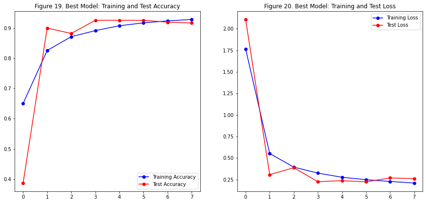

```python
# plot the graph of accuracy
epochs_range = range(len(best_res.history['loss']))

train_acc = best_res.history['accuracy']
test_acc = best_res.history['val_accuracy']
plt.figure(figsize=(15, 15))
plt.subplot(2, 2, 1)
plt.plot(epochs_range, train_acc, label='Training Accuracy', color = "blue", marker = "o")
plt.plot(epochs_range, test_acc, label='Test Accuracy', color = "red", marker = "o")
plt.legend(loc='lower right')
plt.title('Figure 19. Best Model: Training and Test Accuracy')

# plot the graph of loss
train_loss = best_res.history['loss']
test_loss = best_res.history['val_loss']
plt.subplot(2, 2, 2)
plt.plot(epochs_range, train_loss, label='Training Loss', color = "blue", marker = "o")
plt.plot(epochs_range, test_loss, label='Test Loss', color = "red", marker = "o")
plt.legend(loc='upper right')
plt.title('Figure 20. Best Model: Training and Test Loss')
plt.show()
```

```python
# get loss and accuracy score
best_train_loss, best_train_acc = best_model.evaluate(train_generator)
best_test_loss, best_test_acc = best_model.evaluate(test_generator)
print('best_train_loss:', best_train_loss)
print('best_train_acc:', best_train_acc)
print('best_test_loss:', best_test_loss)
print('best_test_acc:', best_test_acc)
```

```
best_train_loss: 0.21503238379955292
best_train_acc: 0.9267399907112122
best_test_loss: 0.2594144940376282
best_test_acc: 0.9169999957084656
```

```python
# make predictions on the test dataset
best_y_predict = best_model.predict(x_test_datagen)
```

```python
# calculate roc_auc_score
best_auc_score = roc_auc_score(y_test, best_y_predict)
print('Best model roc_auc_score:', best_auc_score)
```

```
Best model roc_auc_score: 0.9968944499999999
```

```python
# print out classification report
best_y_pred = np.argmax(best_y_predict, axis= 1)
print(classification_report(y_true, best_y_pred))
```

```
              precision    recall  f1-score   support

           0       0.92      0.95      0.94      1000
           1       0.97      0.96      0.97      1000
           2       0.90      0.93      0.91      1000
           3       0.89      0.82      0.85      1000
           4       0.97      0.90      0.93      1000
           5       0.96      0.73      0.83      1000
           6       0.91      0.97      0.94      1000
           7       0.80      0.99      0.88      1000
           8       0.95      0.96      0.96      1000
           9       0.95      0.97      0.96      1000

    accuracy                           0.92     10000
   macro avg       0.92      0.92      0.92     10000
weighted avg       0.92      0.92      0.92     10000
```

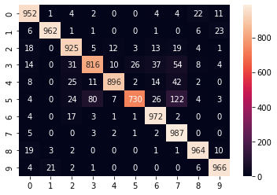

```python
# print out the confusion matrix
best_cm = confusion_matrix(y_true, best_y_pred)
sns.heatmap(best_cm, annot=True, fmt=".0f")
```

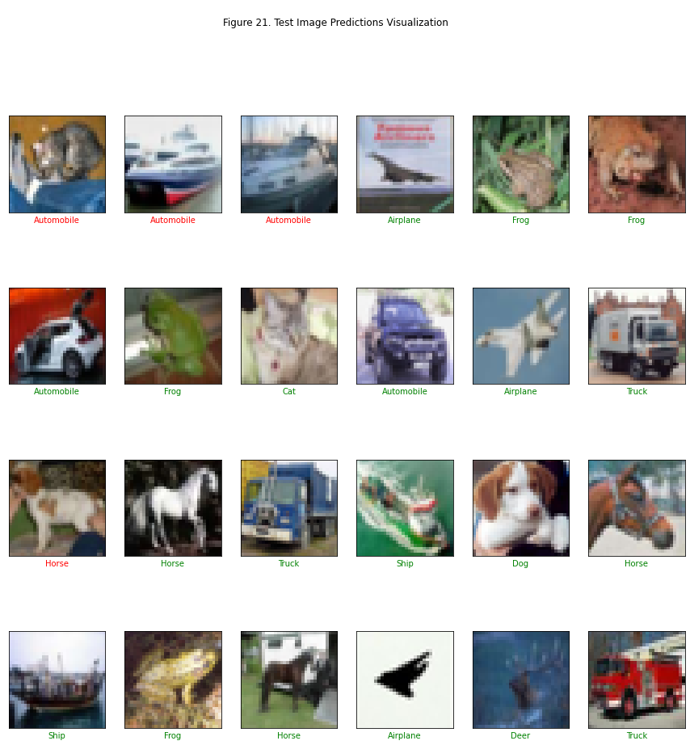

```python
fig, axes = plt.subplots(4, 6, figsize=(15, 15))
for i, ax in enumerate(axes.flat):
  ax.imshow(x_test[i])
  ax.set(xticks=[], yticks=[], xlabel=classes[y_pred1[i]])
  if classes[y_true[i]] == classes[y_pred1[i]]:
    ax.xaxis.label.set_color('green')
  else:
    ax.xaxis.label.set_color('red')
fig.suptitle('\nFigure 21. Test Image Predictions Visualization')
plt.show()
```

## Part 6: Conclusion and Takeaways

In this project, there are 6 parts:

(1) Brief description of the problem and data.  
(2) EDA - Inspect, Visualize, and Clean the data.  
(3) Building and training models:

```
+ Model 1: CNN with two layers
+ Model 2: CNN with two layers adding dropout
+ Model 3: CNN with three layers adding dropout
+ Model 4: CNN with three layers adding Earlystopping and ReduceLROnPlateau
+ Model 5: ResNet50 with "Imagenet" pretrained weights
+ Model 6: ResNet101 with "Imagenet" pretrained weights
```

(4) Results and Analysis:

```
+ Print out results
+ Compare six deep learning models.
```

(5) Tuning hyperparameter to find the best model.  
(6) Conclusion.

The goal of this project is to recognize objects in photos with cifa-10 dataset which contains 60,000 32x32 color images in 10 different categories. These categories represent airplanes, cars, birds, cats, deer, dogs, frogs, horses, ships, and trucks. By comparing six different deep learning models including: CNN with two layers, CNN with two layers adding dropout, CNN with three layers adding dropout, CNN with three layers adding Earlystopping and ReduceLROnPlateau, ResNet50 with "Imagenet" pretrained weights and ResNet101 with "Imagenet" pretrained weights, we can conclude that in this case, ResNet50 with "Imagenet" pretrained weights is the model that has the best performance with the highest roc_auc_score of 0.98, train accuracy of 0.8 and test accuracy of 0.8.

I tried my best and with the result of roc_auc_score of 0.99 and test accuracy 0.92, I think it is good enough, however, because of the limitation of data and the running time was too costly, the models just were trained on limited approach. There are many other ways can improve this kind of project such as:

```
+ building more deep learning models by tuning other hyperparameters to get optimal results such as: try different dropout at each convolutional layer, try with more different learning rate, ...
+ or we can run models by increasing the number of epochs
+ or adding more layers and filters.
```

I believe these ways might get better results.